# Tarea 3 Modelos Lineales

Shanthal Chavarría

2021-09-12

```r
# Residual Sum of Square (RSS)
RSS <- function(Pred,Real) {
  ss <- sum((Real-Pred)^2)
  return(ss)
}
RSE<-function(Pred,Real,NumPred) {
  N<-length(Real)-NumPred-1  # <- length(Real)-(NumPred+1)
  ss<-sqrt((1/N)*RSS(Pred,Real))
  return(ss)
}
MSE <- function(Pred,Real) {
  N<-length(Real)
  ss<-(1/N)*RSS(Pred,Real)
  return(ss)
}
error.relativo <- function(Pred,Real) {
  ss<-sum(abs(Real-Pred))/sum(abs(Real))
  return(ss)
}

# Funciones para desplegar precisión
indices.precision <- function(real, prediccion,cantidad.variables.predictoras) {
  return(list(error.cuadratico = MSE(prediccion,real),
              raiz.error.cuadratico = RSE(prediccion,real,cantidad.variables.predictoras),
              error.relativo = error.relativo(prediccion,real),
              correlacion = as.numeric(cor(prediccion,real))))
}


# Gráfico de dispersión entre el valor real de la variable a predecir y la predicción del modelo.
plot.real.prediccion <- function(real, prediccion, modelo = "") {
  g <- ggplot(data = data.frame(Real = real, Prediccion = as.numeric(prediccion)), mapping = aes(x = Real, y = Prediccion)) +
    geom_point(size = 1, col = "dodgerblue3") +
    labs(title = paste0("Real vs Predicción", ifelse(modelo == "", "", paste(", con", modelo))),
         x = "Real",
         y = "Predicción")
  return(g)
}
```

# Pregunta 1: **[10 puntos]** Explique detalladamente la diferencia entre un problema de regresión y uno de clasificación. Basado en su experiencia laboral o académica comente 2 ejemplos de problemas de clasificación y 2 de regresión que conozca y la oportunidad que ve en resolverlos.

- Clasificación: El objetivo de este es lograr predecir la **clase** a la que pertenecen las observaciones. Este se intenta lograr con un modelo.
1. Clasificar clientes como Deudores o No deudores.
2. Clasificar movimientos banacarios como si fueren estafas o no estafas.
- Regresión: El objetivo de un problema de regresión es primeramente con una variable a predecir númerica, a diferencia de un problema de clasificación, además busca encontrar una función que explique lo más posible el comportamiento de la variable a predecir para así poder dar pronósticos.
1. Predicción de los valores de activos, como se devaluan.
2. Cálculo de número de tarjetas bancarias vendidas y por vender.

# Pregunta 2: **[15 puntos]**

## 1. Programe en lenguaje R una función que reciba como entrada la matriz de confusión (para el caso 2 × 2) que calcule y retorne en una lista: la Precisión Global, el Error Global, la Precisión Positiva (PP), la Precisión Negativa (PN), los Falsos Positivos (FP), los Falsos Negativos (FN), la Asertividad Positiva (AP) y la Asertividad Negativa (NP).

```r
Confusion <- function(MC){
  VN <- MC[1,1]
  FN <- MC[2,1]
  VP <- MC[2,2]
  FP <- MC[1,2]

  PG <- (VN + VP)/(VN + FP + FN + VP)
  EG <- 1 - PG
  PP <- VP/(FN + VP)
  PN <- VN/(FP + VN)
  FP <- FP/(VN + FP)
  FN <- FN/(VP + FN)
  AP <- VP/(FP + VP)
  AN <- VN/(VN + FN)

  Respuesta <- list(PG = PG,EG = EG, PP = PP,PN = PN,FP = FP,FN=FN,AP=AP,AN=AN)

  names(Respuesta) <- c("Precision Global", "Error Global","Precision Positiva", "Precision Negativa", "Falsos Positivos", "Falsos Negativos", "Asertividad Positiva" , "Asertividad Negativa")

  return(Respuesta)
}
```

## 2. Supongamos que tenemos un modelo predictivo para detectar Fraude en Tarjetas de Crédito, la variable a predecir es `Fraude` con dos posibles valores `Sí` (para el caso en que sí fue fraude) y `No` (para el caso en que no fue fraude). Supongamos la matriz de confusión es:

### Calcule la Precisión Global, el Error Global, la Precisión Positiva (PP), la Precisión Negativa (PN), los Falsos Positivos (FP), los Falsos Negativos (FN), la Asertividad Positiva (AP) y la Asertividad Negativa (NP).

```r
MC <- matrix(c(83254,15,879,4), nrow = 2, byrow = TRUE)
MC
```

```
      [,1] [,2]
[1,] 83254   15
[2,]   879    4
```

```r
Confusion(MC)
```

```
$`Precision Global`
[1] 0.9893764

$`Error Global`
[1] 0.01062363

$`Precision Positiva`
[1] 0.004530011

$`Precision Negativa`
[1] 0.9998199

$`Falsos Positivos`
[1] 0.0001801391

$`Falsos Negativos`
[1] 0.99547

$`Asertividad Positiva`
[1] 0.999955

$`Asertividad Negativa`
[1] 0.999988
```

### ¿Es bueno o malo el modelo predictivo? Justifique su respuesta.

# Pregunta 3: **[25 puntos]** En este ejercicio vamos a usar la tabla de `datos wine.csv`, que contiene variantes del vino “Vinho Verde”. Los datos incluyen variables de pruebas fisicoquímicas y sensoriales realizadas a dicho vino.

Para esto realice lo siguiente:

## 1. Cargue la tabla de datos `wine.csv` en R.

```r
datos <- read.table("datos/wine.csv", dec = ".", sep = ",", header = T,stringsAsFactors = T)

datos$calidad <- as.factor(datos$calidad)

str(datos)
```

```
'data.frame':   6497 obs. of  13 variables:
 $ fija.acidez          : num  6.2 6.6 6.4 7 6.4 5.9 5.6 5.5 5.9 7.2 ...
 $ volatil.acidez       : num  0.3 0.61 0.32 0.22 0.43 0.44 0.19 0.21 0.29 0.27 ...
 $ citrica.acidez       : num  0.21 0.01 0.23 0.29 0.27 0 0.26 0.25 0.25 0.42 ...
 $ residual.azucar      : num  1.1 1.9 16.2 8.9 1.1 1.6 1.4 1.2 13.4 1.6 ...
 $ cloruros             : num  0.032 0.08 0.055 0.05 0.054 0.042 0.03 0.04 0.067 0.05 ...
 $ libre.sulfuro.dioxido: num  31 8 36 24 5 3 12 18 72 35 ...
 $ total.sulfuro.dioxido: num  111 25 176 90 110 11 76 75 160 135 ...
 $ densidad             : num  0.989 0.997 0.999 0.996 0.994 ...
 $ pH                   : num  2.97 3.69 3.26 3.29 3.24 3.48 3.25 3.31 3.33 2.94 ...
 $ sulfitos             : num  0.42 0.73 0.54 0.46 0.52 0.85 0.37 0.56 0.54 0.46 ...
 $ alcohol              : num  12.2 10.5 9.1 9.8 9.1 11.7 10.9 11.3 10.3 11 ...
 $ calidad              : Factor w/ 7 levels "3","4","5","6",..: 4 3 3 4 2 4 5 4 4 4 ...
 $ tipo                 : Factor w/ 2 levels "blanco","tinto": 1 2 1 1 1 2 1 1 2 1 ...
```

## 2. ¿Es este problema equilibrado o desequilibrado? Justifique su respuesta.

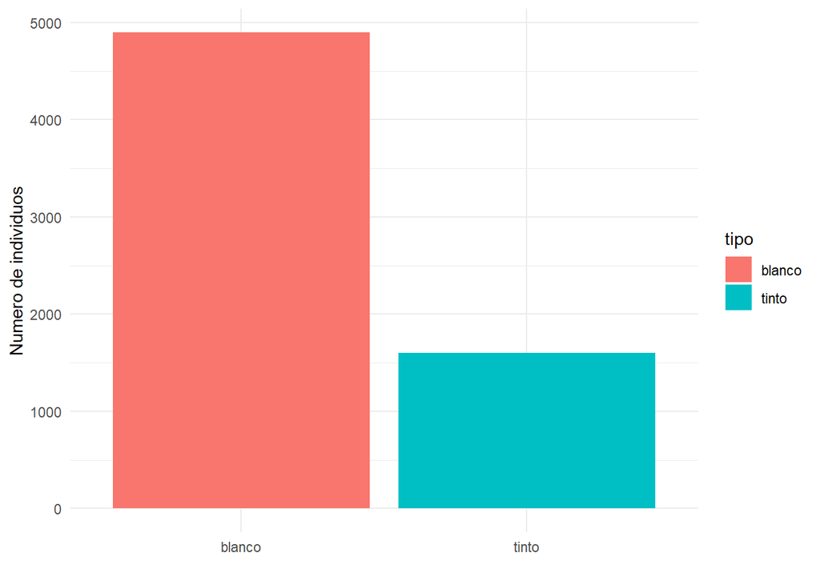

```r
library(ggplot2)
library(dplyr)

datos%>%
  select(tipo)%>%
  ggplot(aes(x=tipo, fill = tipo))+
  geom_bar()+
  theme_minimal()+
  labs(y= "Numero de individuos", x = " ")
```

Es un problema desequilibrado el número de observaciónes de tipo blanco son más que el doble de observaciones de tinto.

## 3. Use el método de K vecinos más cercanos en `traineR` (con los parámetros por defecto) para generar un modelo predictivo para la tabla `wine.csv` usando el 80 % de los datos para la tabla aprendizaje y un 20 % para la tabla testing, luego calcule para los datos de testing la matriz de confusión, la precisión global y la precisión para cada una de las categorías. ¿Son buenos los resultados? Explique.

```r
library(traineR)
tamaño <- dim(datos)
n <- tamaño[1]

muestra <- sample(1:n, floor(n*0.80))
testing <- datos[-muestra,]
aprendizaje <- datos[muestra,]

modelo.knn <- train.knn(tipo~., data = aprendizaje, kmax = floor(sqrt(n)) )

modelo.knn
```

```
Call:
kknn::train.kknn(formula = tipo ~ ., data = aprendizaje, kmax = floor(sqrt(n)))

Type of response variable: nominal
Minimal misclassification: 0.006734655
Best kernel: optimal
Best k: 5
```

```r
prediccion <- predict(modelo.knn, testing, type = "class")


MC.knn <- confusion.matrix(testing ,prediccion)

indices <- general.indexes(mc = MC.knn)

indices
```

```
Confusion Matrix:
        prediction
real     blanco tinto
  blanco    988     1
  tinto       5   306

Overall Accuracy: 0.9954
Overall Error:    0.0046

Category Accuracy:

       blanco        tinto
     0.998989     0.983923
```

Son muy bueno resultados, tanto para la precisión global, como la precisión por categoría.

## 4. Repita el item 3, pero esta vez, usando el menú de Poder Predictivo seleccione las 6 variables que, según su criterio, tienen mejor poder predictivo. ¿Mejoran los resultados?

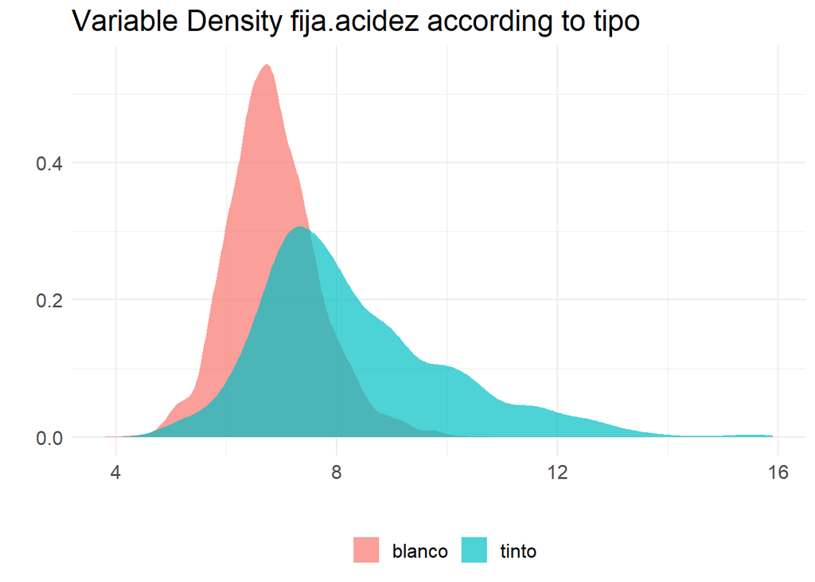

```r
numerical.predictive.power(datos, "tipo", "fija.acidez")
```

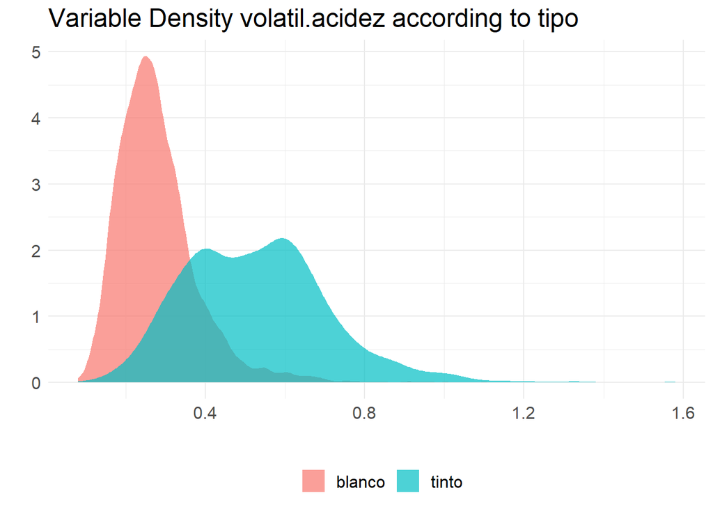

```r
numerical.predictive.power(datos, "tipo", "volatil.acidez")
```

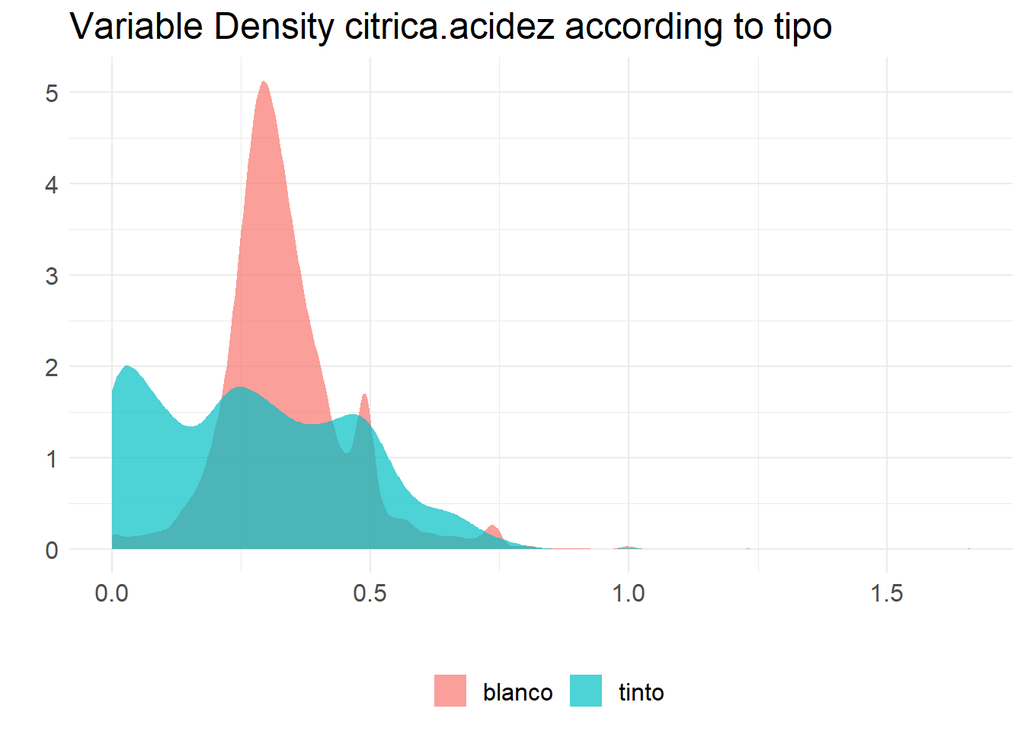

```r
numerical.predictive.power(datos, "tipo", "citrica.acidez")
```

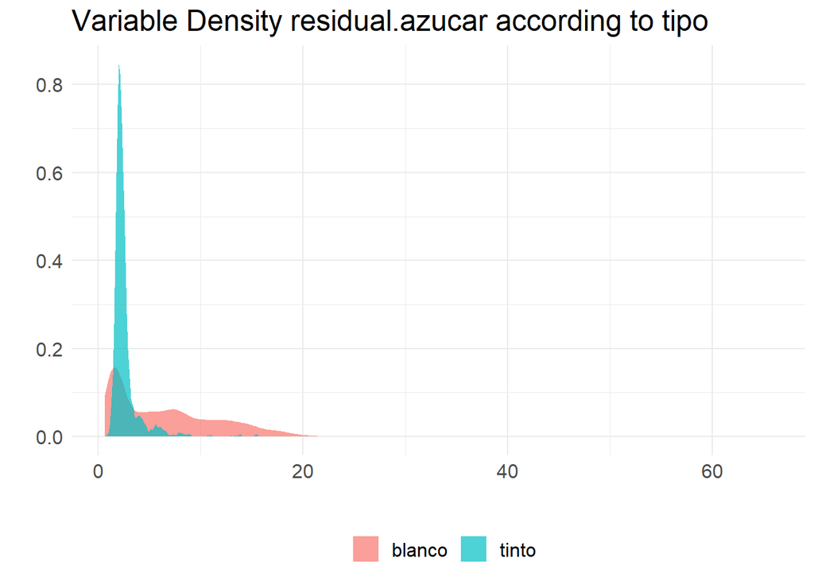

```r
numerical.predictive.power(datos, "tipo", "residual.azucar")
```

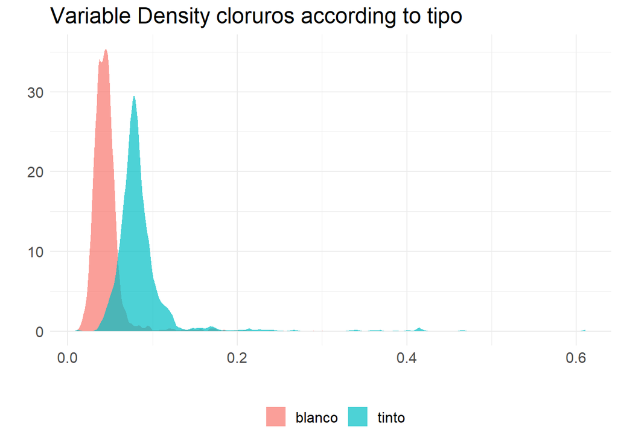

```r
numerical.predictive.power(datos, "tipo", "cloruros")
```

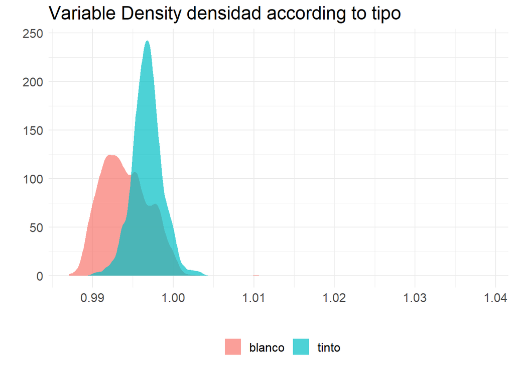

```r
numerical.predictive.power(datos, "tipo", "densidad")
```

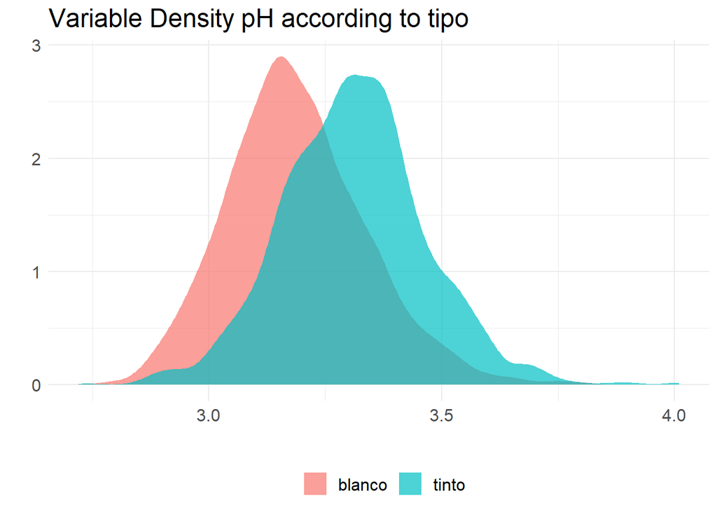

```r
numerical.predictive.power(datos, "tipo", "pH")
```

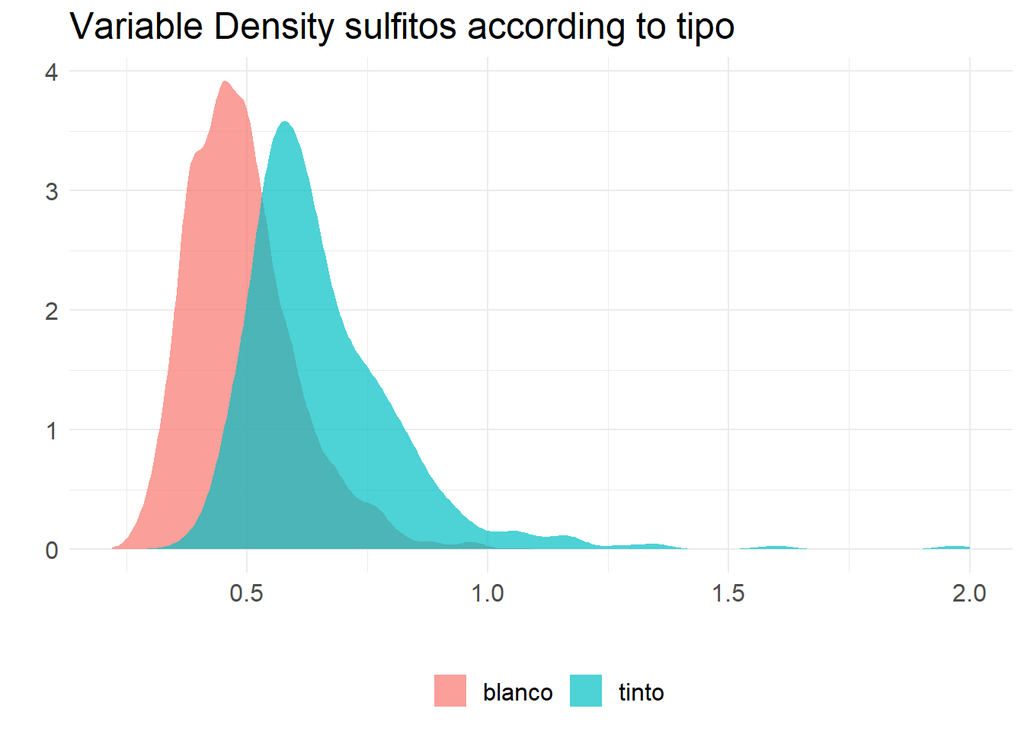

```r
numerical.predictive.power(datos, "tipo", "sulfitos")
```

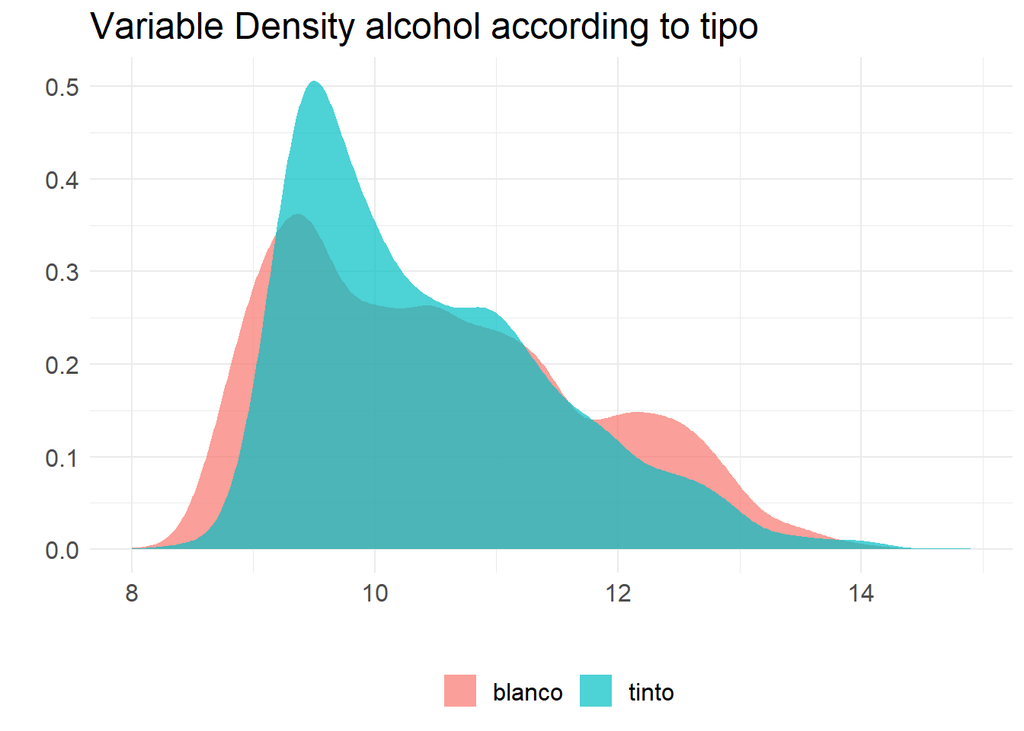

```r
numerical.predictive.power(datos, "tipo", "alcohol")
```

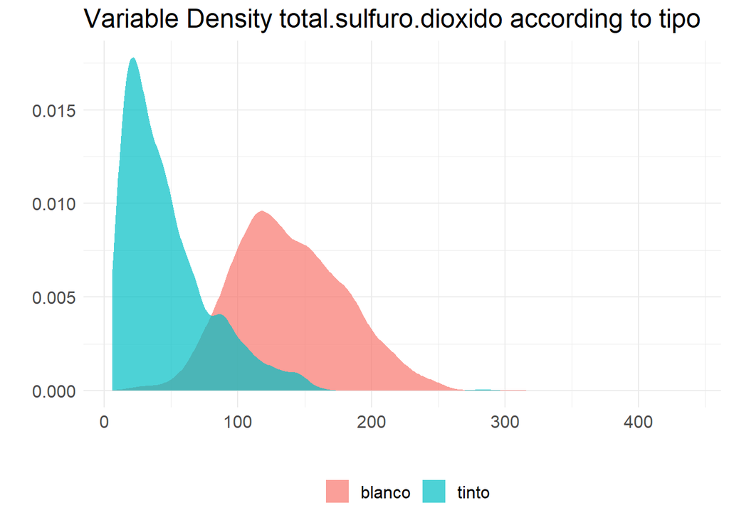

```r
numerical.predictive.power(datos, "tipo", "total.sulfuro.dioxido")
```

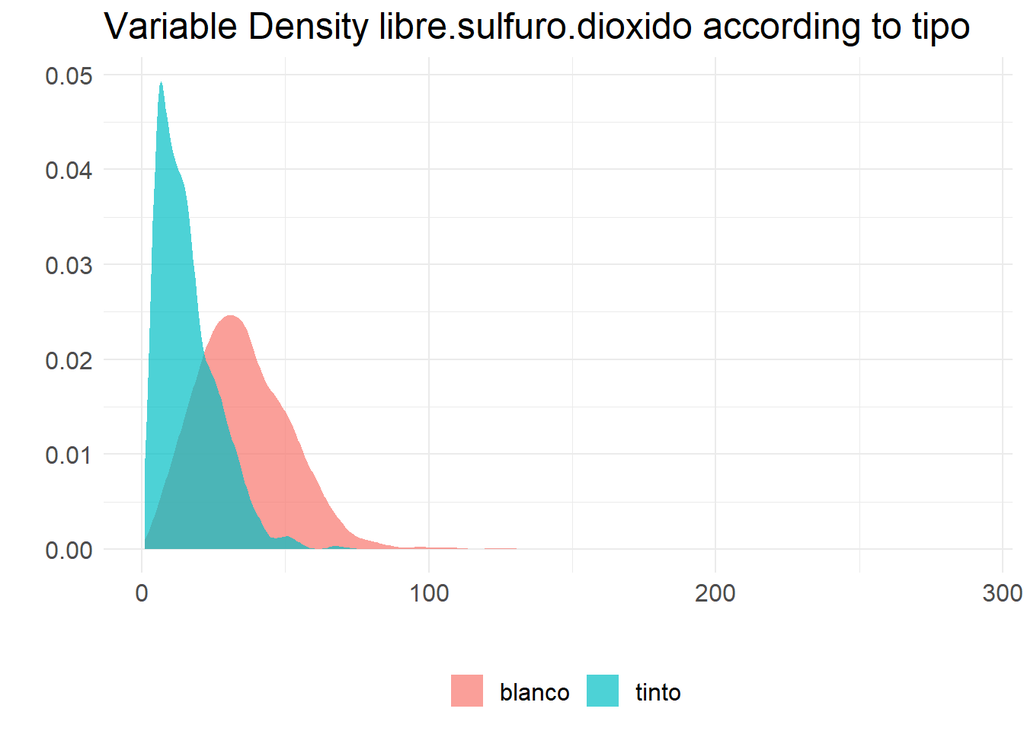

```r
numerical.predictive.power(datos, "tipo", "libre.sulfuro.dioxido")
```

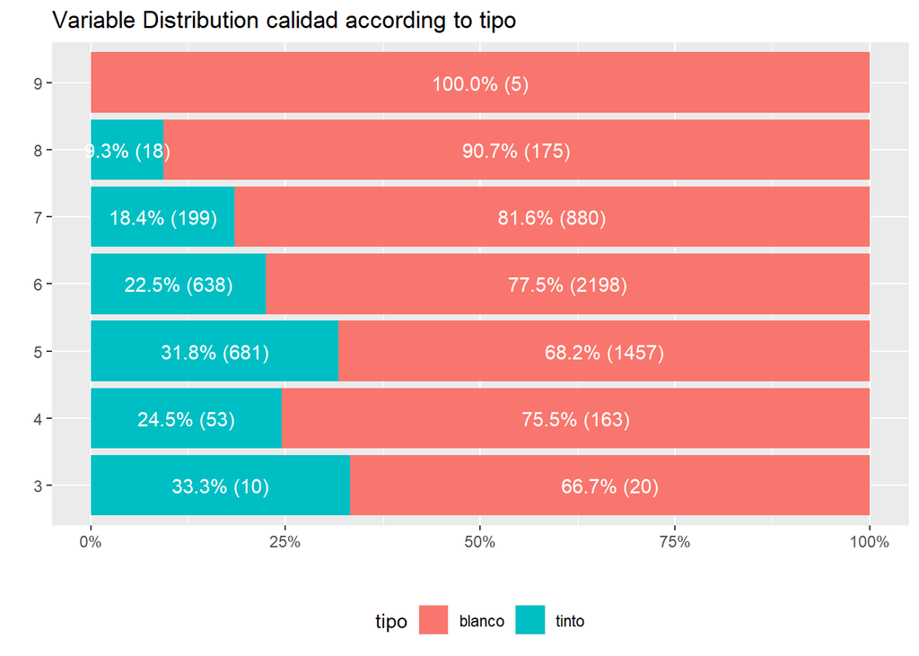

```r
categorical.predictive.power(datos,"tipo","calidad")
```

```r
modelo.knn <- train.knn(tipo~cloruros + pH + sulfitos + total.sulfuro.dioxido + volatil.acidez + densidad, data = aprendizaje, kmax = floor(sqrt(n)) )

modelo.knn
```

```
Call:
kknn::train.kknn(formula = tipo ~ cloruros + pH + sulfitos +     total.sulfuro.dioxido + volatil.acidez + densidad, data = aprendizaje,     kmax = floor(sqrt(n)))

Type of response variable: nominal
Minimal misclassification: 0.007119492
Best kernel: optimal
Best k: 12
```

```r
prediccion <- predict(modelo.knn, testing, type = "class")

MC<- confusion.matrix(testing ,prediccion)

indices1 <- general.indexes(mc = MC)

indices1
```

```
Confusion Matrix:
        prediction
real     blanco tinto
  blanco    987     2
  tinto       4   307

Overall Accuracy: 0.9954
Overall Error:    0.0046

Category Accuracy:

       blanco        tinto
     0.997978     0.987138
```

Eligiendo las variables `cloruros`,`pH`,`sulfitos`, `total.sulfuro.dioxido`, `volatil.acidez,densidad` mejoraron en un punto la precisión de `tinto`.

5. Genere un Modelo Predictivo usando K vecinos más cercanos para cada uno de los siguientes núcleos: `rectangular`, `triangular`, `epanechnikov`, `biweight`, `triweight`, `cos`, `inv`, `gaussian` y `optimal` ¿Cuál produce los mejores resultados?

### Rectangular

```r
modelo.rectangular <- train.knn(tipo~., data = aprendizaje, kernel = "rectangular")

prediccion <- predict(modelo.rectangular, testing, type = "class")

MC<- confusion.matrix(testing ,prediccion)

rectangular <- general.indexes(mc = MC)
rectangular
```

```
Confusion Matrix:
        prediction
real     blanco tinto
  blanco    986     3
  tinto       4   307

Overall Accuracy: 0.9946
Overall Error:    0.0054

Category Accuracy:

       blanco        tinto
     0.996967     0.987138
```

### Triangular

```r
modelo.triangular <- train.knn(tipo~., data = aprendizaje, kernel = "triangular")

prediccion <- predict(modelo.triangular, testing, type = "class")

MC<- confusion.matrix(testing ,prediccion)
triangular <- general.indexes(mc = MC)
triangular
```

```
Confusion Matrix:
        prediction
real     blanco tinto
  blanco    987     2
  tinto       3   308

Overall Accuracy: 0.9962
Overall Error:    0.0038

Category Accuracy:

       blanco        tinto
     0.997978     0.990354
```

### Epanechnikov

```r
modelo.epanechnikov <- train.knn(tipo~., data = aprendizaje, kernel = "epanechnikov")

prediccion <- predict(modelo.epanechnikov, testing, type = "class")

MC<- confusion.matrix(testing ,prediccion)
epanechnikov <- general.indexes(mc = MC)

epanechnikov
```

```
Confusion Matrix:
        prediction
real     blanco tinto
  blanco    988     1
  tinto       4   307

Overall Accuracy: 0.9962
Overall Error:    0.0038

Category Accuracy:

       blanco        tinto
     0.998989     0.987138
```

### Biweight

```r
modelo.biweight <- train.knn(tipo~., data = aprendizaje, kernel = "biweight")

prediccion <- predict(modelo.biweight, testing, type = "class")

MC<- confusion.matrix(testing ,prediccion)
biweight <- general.indexes(mc = MC)

biweight
```

```
Confusion Matrix:
        prediction
real     blanco tinto
  blanco    985     4
  tinto       5   306

Overall Accuracy: 0.9931
Overall Error:    0.0069

Category Accuracy:

       blanco        tinto
     0.995956     0.983923
```

### Triweight

```r
modelo.triweight <- train.knn(tipo~., data = aprendizaje, kernel = "triweight")

prediccion <- predict(modelo.triweight, testing, type = "class")

MC<- confusion.matrix(testing ,prediccion)
triweight <- general.indexes(mc = MC)

triweight
```

```
Confusion Matrix:
        prediction
real     blanco tinto
  blanco    987     2
  tinto       4   307

Overall Accuracy: 0.9954
Overall Error:    0.0046

Category Accuracy:

       blanco        tinto
     0.997978     0.987138
```

### Cos

```r
modelo.cos <- train.knn(tipo~., data = aprendizaje, kernel = "cos")

prediccion <- predict(modelo.cos, testing, type = "class")

MC<- confusion.matrix(testing ,prediccion)
cos <- general.indexes(mc = MC)
cos
```

```
Confusion Matrix:
        prediction
real     blanco tinto
  blanco    986     3
  tinto       4   307

Overall Accuracy: 0.9946
Overall Error:    0.0054

Category Accuracy:

       blanco        tinto
     0.996967     0.987138
```

### inv

```r
modelo.inv <- train.knn(tipo~., data = aprendizaje, kernel = "inv")

prediccion <- predict(modelo.inv, testing, type = "class")

MC<- confusion.matrix(testing ,prediccion)
inv <- general.indexes(mc = MC)

inv
```

```
Confusion Matrix:
        prediction
real     blanco tinto
  blanco    985     4
  tinto       4   307

Overall Accuracy: 0.9938
Overall Error:    0.0062

Category Accuracy:

       blanco        tinto
     0.995956     0.987138
```

### Gaussian

```r
modelo.gaussian <- train.knn(tipo~., data = aprendizaje, kernel = "gaussian")

prediccion <- predict(modelo.gaussian, testing, type = "class")

MC<- confusion.matrix(testing ,prediccion)
gaussian <- general.indexes(mc = MC)

gaussian
```

```
Confusion Matrix:
        prediction
real     blanco tinto
  blanco    986     3
  tinto       4   307

Overall Accuracy: 0.9946
Overall Error:    0.0054

Category Accuracy:

       blanco        tinto
     0.996967     0.987138
```

### Optimal

```r
modelo.optimal <- train.knn(tipo~., data = aprendizaje, kernel = "optimal")

prediccion <- predict(modelo.optimal, testing, type = "class")

MC<- confusion.matrix(testing ,prediccion)
optimal <- general.indexes(mc = MC)

optimal
```

```
Confusion Matrix:
        prediction
real     blanco tinto
  blanco    988     1
  tinto       5   306

Overall Accuracy: 0.9954
Overall Error:    0.0046

Category Accuracy:

       blanco        tinto
     0.998989     0.983923
```

```r
precisiones.knn <- rbind(as.data.frame(rectangular[2]),as.data.frame(triangular[2]),as.data.frame(epanechnikov[2]),as.data.frame(biweight[2]),as.data.frame(triweight[2]),as.data.frame(cos[2]),as.data.frame(inv[2]),as.data.frame(gaussian[2]), as.data.frame(optimal[2]))

colnames(precisiones.knn) <- c("PrecisionGlobal")

rownames(precisiones.knn) <- c("rectangular", "triangular", "epanechnikov", "biweight", "triweight", "cos",
"inv", "gaussian","optimal")

precisiones.knn
```

|  | PrecisionGlobal |
| --- | --- |
| rectangular | 0.9946154 |
| triangular | 0.9961538 |
| epanechnikov | 0.9961538 |
| biweight | 0.9930769 |
| triweight | 0.9953846 |
| cos | 0.9946154 |
| inv | 0.9938462 |
| gaussian | 0.9946154 |
| optimal | 0.9953846 |

```r
precisiones.knn %>%
  arrange(desc(PrecisionGlobal))
```

|  | PrecisionGlobal |
| --- | --- |
| triangular | 0.9961538 |
| epanechnikov | 0.9961538 |
| triweight | 0.9953846 |
| optimal | 0.9953846 |
| rectangular | 0.9946154 |
| cos | 0.9946154 |
| gaussian | 0.9946154 |
| inv | 0.9938462 |
| biweight | 0.9930769 |

# Pregunta 4: **[25 puntos]** Un cliente nos contrata esta vez para aplicar un modelo no paramétrico con el fin de estudiar una posible oportunidad de negocio, y para ver si le es rentable quiere una predicción de las ventas potenciales de asientos de niños para autos en su tienda. Para ello nos proporciona la tabla de datos `AsientosNinno.csv` que contiene detalles de ventas de asientos de niños para auto en una serie de tiendas similares a las del cliente, y además los datos incluyen variables que definen características de la tienda y su localidad. La tabla de datos está formada por 400 filas y 13 columnas.

Cargue la tabla de datos en `R` y no elimine los NA. En caso de ser necesario, recodificar las variables de forma adecuada. Para medir el error tome un 20 % de la tabla de datos. Realice lo siguiente:

```r
datos <- read.table("datos/AsientosNinno.csv", sep = ";", dec = ".", header = T)[,-1]

datos <- na.omit(datos)

datos$CalidadEstant <- factor(datos$CalidadEstant,levels = c("Malo","Medio","Bueno"), ordered=TRUE)

numero.predictoras <- dim(datos)[2] - 1
numero.filas <- dim(datos)[1]
muestra <- sample(1:numero.filas,numero.filas*0.20)
aprendizaje <- datos[-muestra, ]
testing <- datos[muestra, ]
```

```r
# Gráfico de dispersión entre el valor real de la variable a predecir y la predicción del modelo.
plot.real.prediccion <- function(real, prediccion, modelo = "") {
  g <- ggplot(data = data.frame(Real = real, Prediccion = as.numeric(prediccion)), mapping = aes(x = Real, y = Prediccion)) +
    geom_point(size = 1, col = "dodgerblue3") +
    labs(title = paste0("Real vs Predicción", ifelse(modelo == "", "", paste(", con", modelo))),
         x = "Real",
         y = "Predicción")
  return(g)
}
```

# 1. Genere un modelo de regresión con KNN usando cada unos de los kernels disponibles. Identifique el kernel que da un mejor resultado en la tabla de testing e interprete las medidas de error.

### Rectangular

```r
library(traineR)
library(caret)

modelo.rectangular <- train.knn(Ventas~., data = aprendizaje, kernel = "rectangular")

prediccion <- predict(modelo.rectangular, testing)

pre.rectangular <- indices.precision(testing$Ventas ,prediccion$prediction,numero.predictoras)

pre.rectangular
```

```
$error.cuadratico
[1] 3.450585

$raiz.error.cuadratico
[1] 2.029803

$error.relativo
[1] 0.2148119

$correlacion
[1] 0.7178074
```

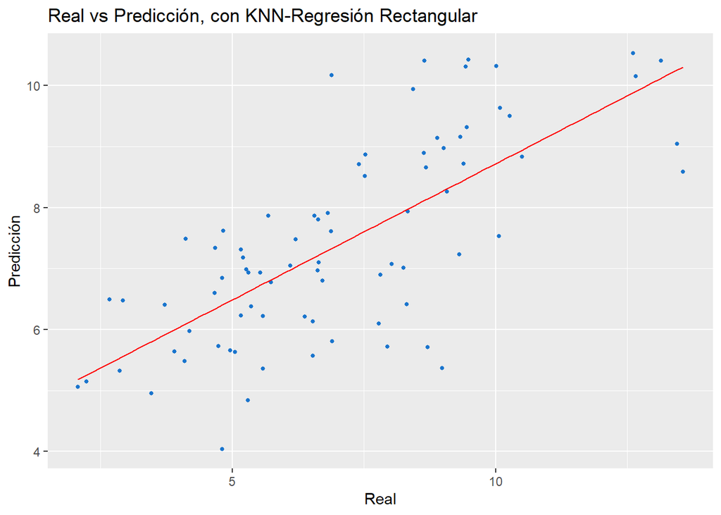

```r
g <- plot.real.prediccion(testing$Ventas, prediccion$prediction, modelo = "KNN-Regresión Rectangular")
g + geom_smooth(method = lm, size = 0.4, color = "red", se = FALSE)
```

### Triangular

```r
modelo.triangular <- train.knn(Ventas~., data = aprendizaje, kernel = "triangular")

prediccion <- predict(modelo.triangular, testing)

pre.triangular <- indices.precision(testing$Ventas ,prediccion$prediction,numero.predictoras)

pre.triangular
```

```
$error.cuadratico
[1] 3.254068

$raiz.error.cuadratico
[1] 1.971156

$error.relativo
[1] 0.2080599

$correlacion
[1] 0.7410579
```

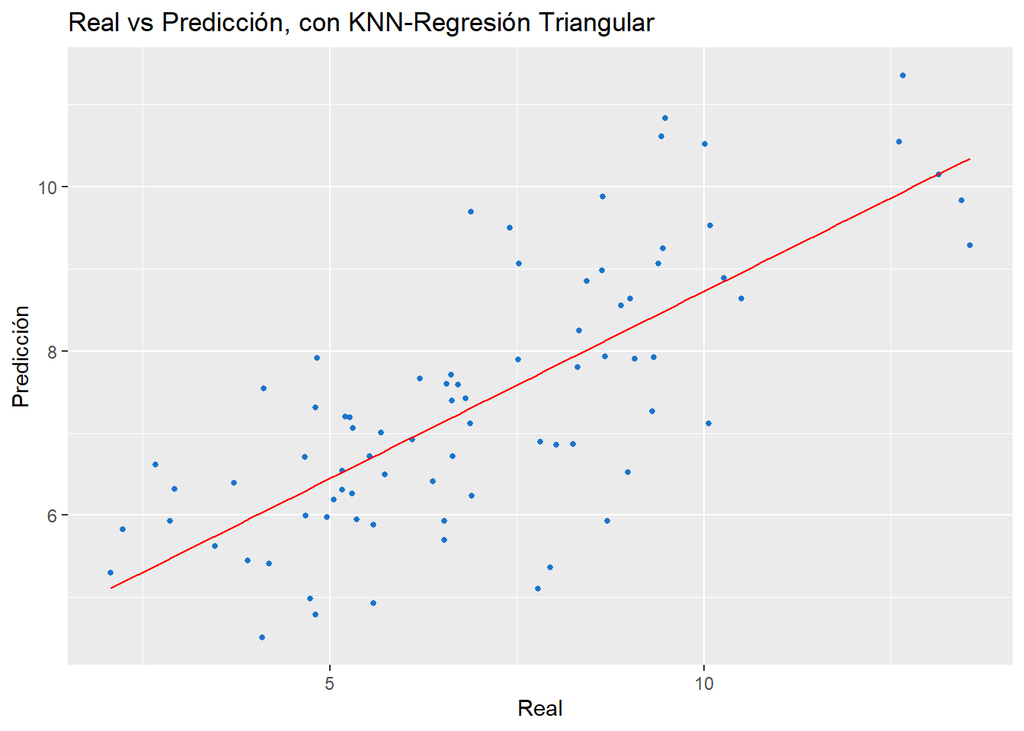

```r
g <- plot.real.prediccion(testing$Ventas, prediccion$prediction, modelo = "KNN-Regresión Triangular")
g + geom_smooth(method = lm, size = 0.4, color = "red", se = FALSE)
```

### Epanechnikov

```r
modelo.epanechnikov <- train.knn(Ventas~., data = aprendizaje, kernel = "epanechnikov")

prediccion <- predict(modelo.epanechnikov, testing)

pre.epanechnikov <- indices.precision(testing$Ventas ,prediccion$prediction,numero.predictoras)

pre.epanechnikov
```

```
$error.cuadratico
[1] 3.26998

$raiz.error.cuadratico
[1] 1.975969

$error.relativo
[1] 0.2090484

$correlacion
[1] 0.742035
```

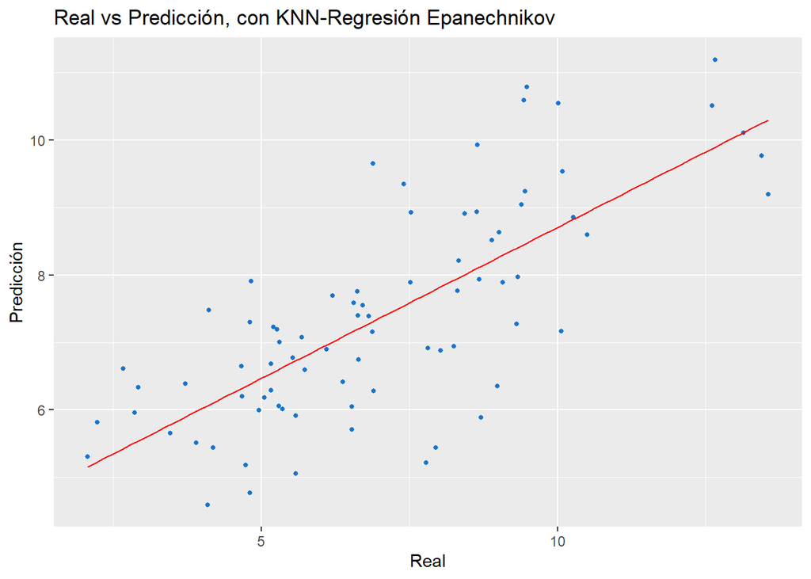

```r
g <- plot.real.prediccion(testing$Ventas, prediccion$prediction, modelo = "KNN-Regresión Epanechnikov")

g + geom_smooth(method = lm, size = 0.4, color = "red", se = FALSE)
```

### Biweight

```r
modelo.biweight <- train.knn(Ventas~., data = aprendizaje, kernel = "biweight")

prediccion <- predict(modelo.biweight, testing)

pre.biweight <- indices.precision(testing$Ventas ,prediccion$prediction,numero.predictoras)

pre.biweight
```

```
$error.cuadratico
[1] 3.24141

$raiz.error.cuadratico
[1] 1.967318

$error.relativo
[1] 0.2023715

$correlacion
[1] 0.7344831
```

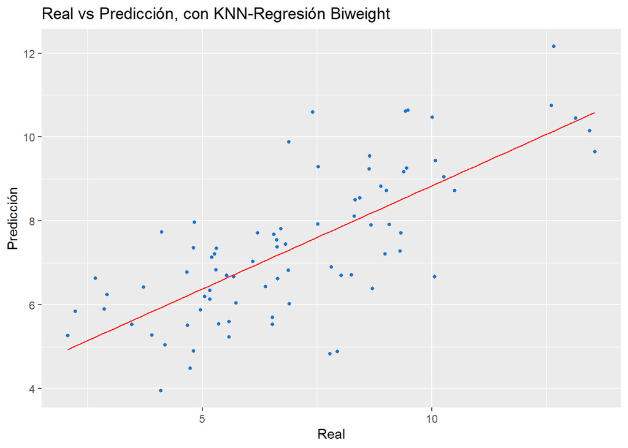

```r
g <- plot.real.prediccion(testing$Ventas, prediccion$prediction, modelo = "KNN-Regresión Biweight")
g + geom_smooth(method = lm, size = 0.4, color = "red", se = FALSE)
```

### Triweight

```r
modelo.triweight <- train.knn(Ventas~., data = aprendizaje, kernel = "triweight")

prediccion <- predict(modelo.triweight, testing)

pre.triweight <- indices.precision(testing$Ventas ,prediccion$prediction,numero.predictoras)

pre.triweight
```

```
$error.cuadratico
[1] 3.516555

$raiz.error.cuadratico
[1] 2.049115

$error.relativo
[1] 0.2109071

$correlacion
[1] 0.702476
```

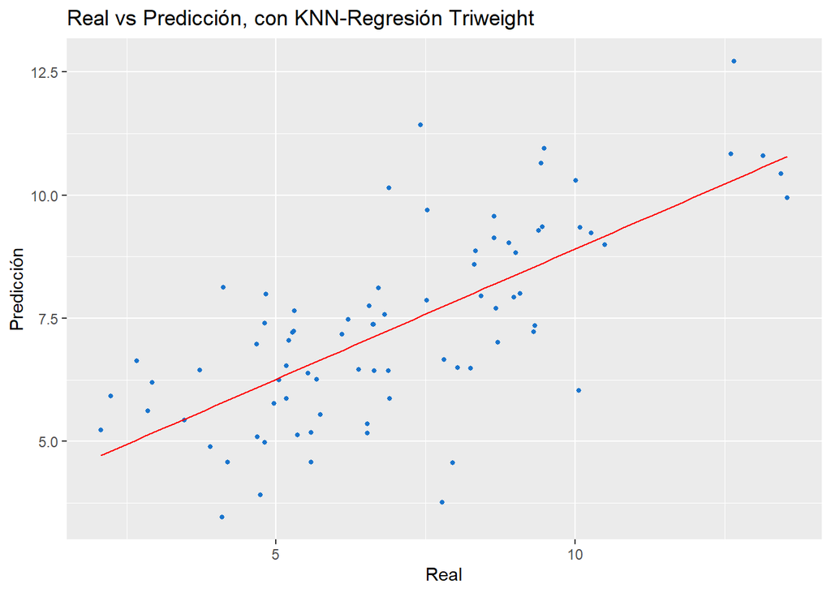

```r
g <- plot.real.prediccion(testing$Ventas, prediccion$prediction, modelo = "KNN-Regresión Triweight")
g + geom_smooth(method = lm, size = 0.4, color = "red", se = FALSE)
```

### Cos

```r
modelo.cos <- train.knn(Ventas~., data = aprendizaje, kernel = "cos")

prediccion <- predict(modelo.cos, testing)

pre.cos <- indices.precision(testing$Ventas ,prediccion$prediction,numero.predictoras)

pre.cos
```

```
$error.cuadratico
[1] 3.260368

$raiz.error.cuadratico
[1] 1.973063

$error.relativo
[1] 0.2084627

$correlacion
[1] 0.7412604
```

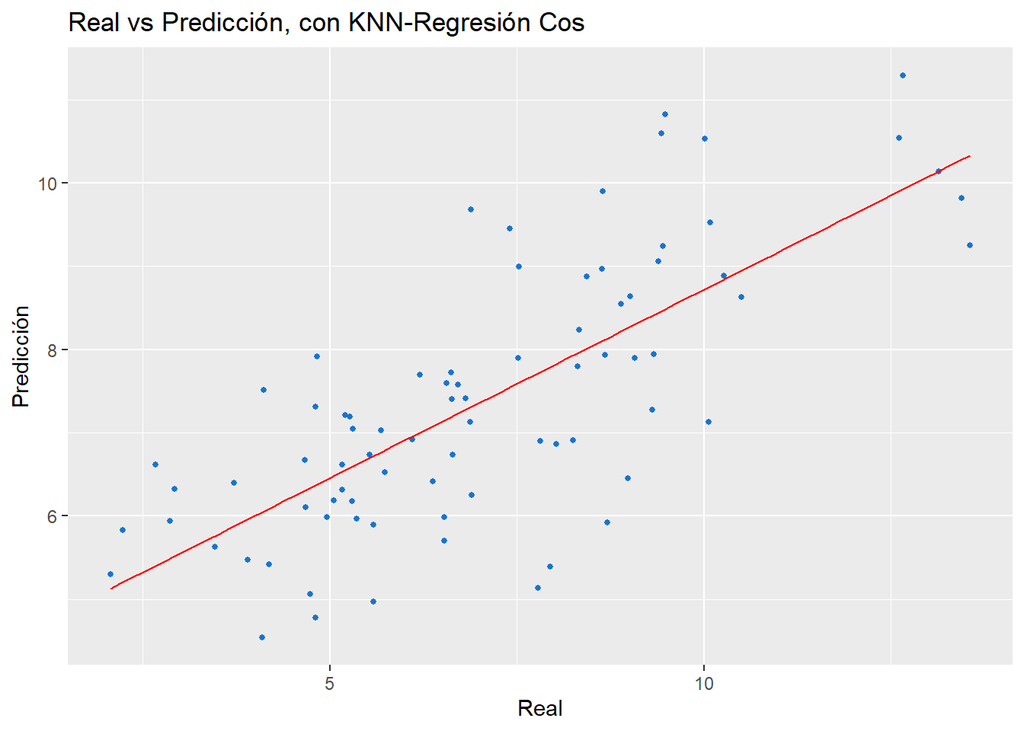

```r
g <- plot.real.prediccion(testing$Ventas, prediccion$prediction, modelo = "KNN-Regresión Cos")
g + geom_smooth(method = lm, size = 0.4, color = "red", se = FALSE)
```

### inv

```r
modelo.inv <- train.knn(Ventas~., data = aprendizaje, kernel = "inv")

prediccion <- predict(modelo.inv, testing)

pre.inv <- indices.precision(testing$Ventas ,prediccion$prediction,numero.predictoras)

pre.inv
```

```
$error.cuadratico
[1] 3.306646

$raiz.error.cuadratico
[1] 1.987016

$error.relativo
[1] 0.2103861

$correlacion
[1] 0.7335815
```

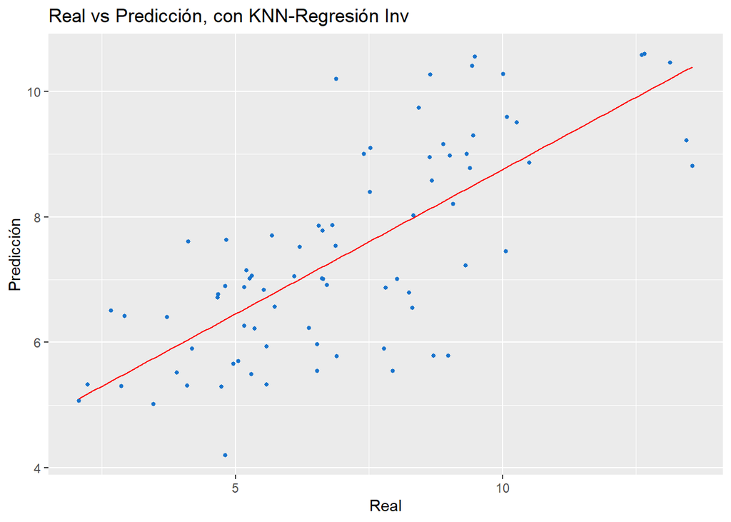

```r
g <- plot.real.prediccion(testing$Ventas, prediccion$prediction, modelo = "KNN-Regresión Inv")
g + geom_smooth(method = lm, size = 0.4, color = "red", se = FALSE)
```

### Gaussian

```r
modelo.gaussian <- train.knn(Ventas~., data = aprendizaje, kernel = "gaussian")

prediccion <- predict(modelo.gaussian, testing)

pre.gaussian <- indices.precision(testing$Ventas ,prediccion$prediction,numero.predictoras)

pre.gaussian
```

```
$error.cuadratico
[1] 3.497643

$raiz.error.cuadratico
[1] 2.043597

$error.relativo
[1] 0.2154204

$correlacion
[1] 0.7228439
```

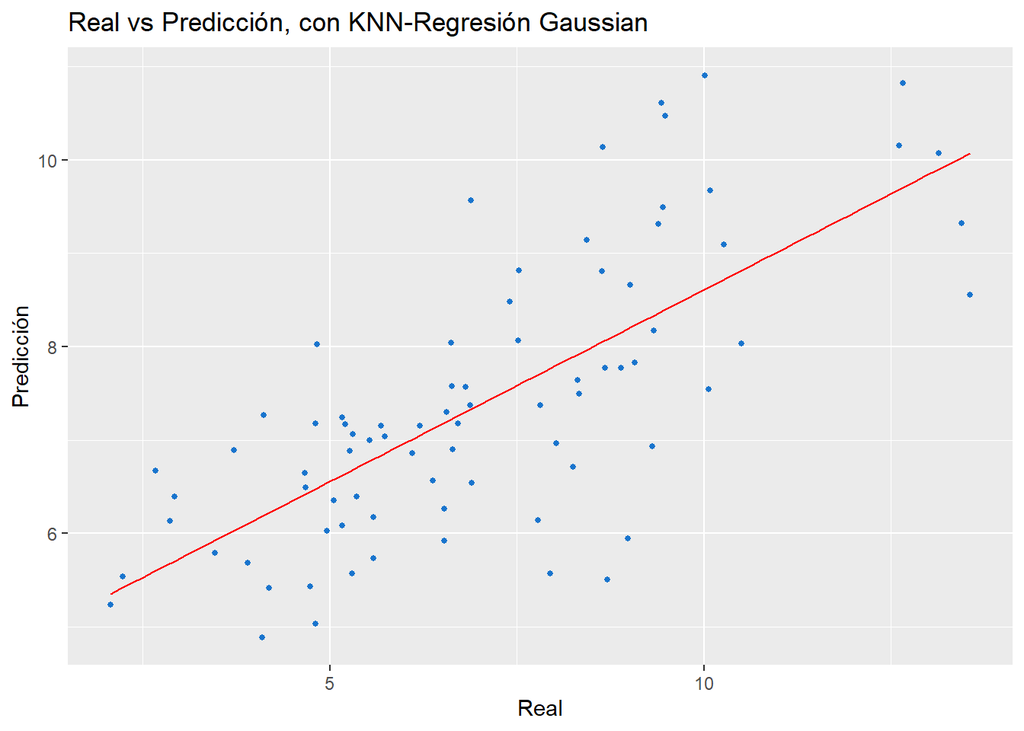

```r
g <- plot.real.prediccion(testing$Ventas, prediccion$prediction, modelo = "KNN-Regresión Gaussian")
g + geom_smooth(method = lm, size = 0.4, color = "red", se = FALSE)
```

### Optimal

```r
modelo.optimal <- train.knn(Ventas~., data = aprendizaje, kernel = "optimal")

prediccion <- predict(modelo.optimal, testing)

pre.optimal <- indices.precision(testing$Ventas ,prediccion$prediction,numero.predictoras)

pre.optimal
```

```
$error.cuadratico
[1] 3.272884

$raiz.error.cuadratico
[1] 1.976846

$error.relativo
[1] 0.206014

$correlacion
[1] 0.7436196
```

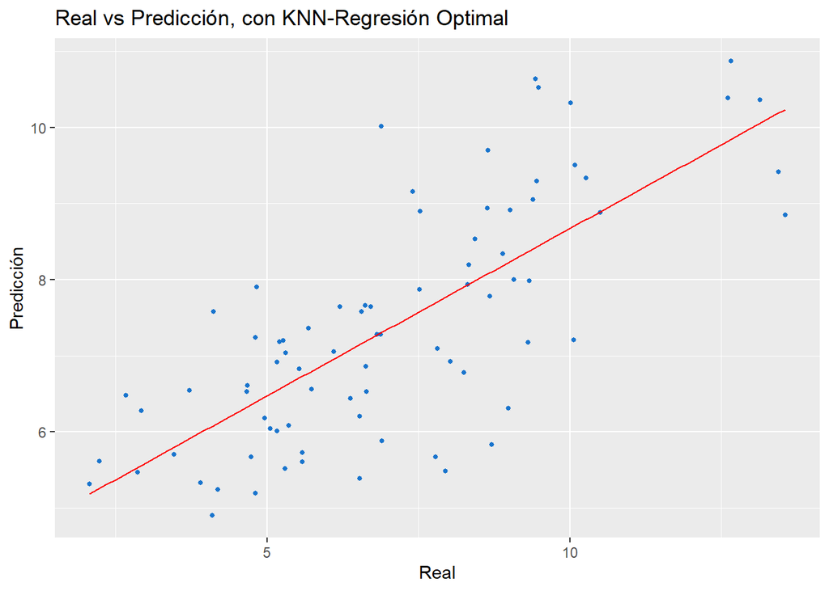

```r
g <- plot.real.prediccion(testing$Ventas, prediccion$prediction, modelo = "KNN-Regresión Optimal")
g + geom_smooth(method = lm, size = 0.4, color = "red", se = FALSE)
```

El modelo que da mejores resultados es el `epanechnikov`, tiene menor error y mejor correlación.

## 2. Esta tabla contiene algunas variables muy correlacionadas, descarte al menos 2 variables predictoras e indique la razón. Corra nuevamente una regresión con KNN e identifique el kernel que da mejores resultados. ¿Mejora el resultado respecto al modelo seleccionado en el inciso anterior?

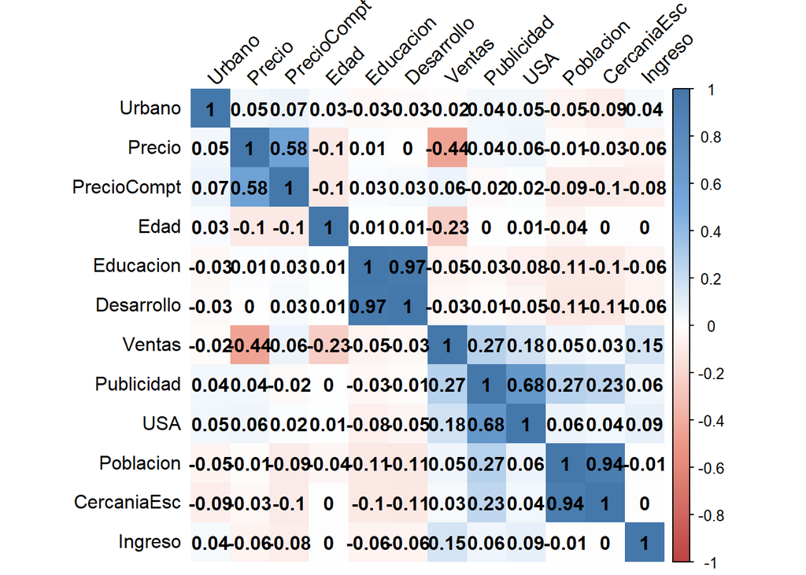

```r
library(corrplot)

matriz.correlacion<-cor(datos[,-8])


col <- colorRampPalette(c("#BB4444", "#EE9988", "#FFFFFF", "#77AADD", "#4477AA"))
corrplot(matriz.correlacion, method="shade", shade.col=NA, tl.col="black", tl.srt=45,
col=col(200), addCoef.col="black", order="AOE")
```

```r
library("ggplot2")

#elimino las variables
aprendizaje <- aprendizaje[,-c(4,13)]
testing <- testing[,-c(4,13)]
```

### Rectangular

```r
modelo.rectangular <- train.knn(Ventas~., data = aprendizaje, kernel = "rectangular")

prediccion <- predict(modelo.rectangular, testing)

pre.rectangular <- indices.precision(testing$Ventas ,prediccion$prediction,numero.predictoras)

pre.rectangular
```

```
$error.cuadratico
[1] 3.196706

$raiz.error.cuadratico
[1] 1.953705

$error.relativo
[1] 0.1952653

$correlacion
[1] 0.7526139
```

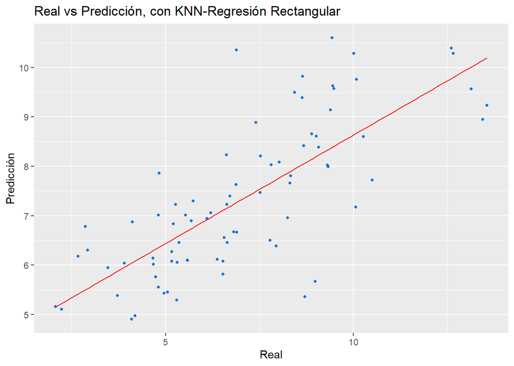

```r
g <- plot.real.prediccion(testing$Ventas, prediccion$prediction, modelo = "KNN-Regresión Rectangular")
g + geom_smooth(method = lm, size = 0.4, color = "red", se = FALSE)
```

### Triangular

```r
modelo.triangular <- train.knn(Ventas~., data = aprendizaje, kernel = "triangular")

prediccion <- predict(modelo.triangular, testing)

pre.triangular <- indices.precision(testing$Ventas ,prediccion$prediction,numero.predictoras)

pre.triangular
```

```
$error.cuadratico
[1] 2.985958

$raiz.error.cuadratico
[1] 1.888206

$error.relativo
[1] 0.190782

$correlacion
[1] 0.76144
```

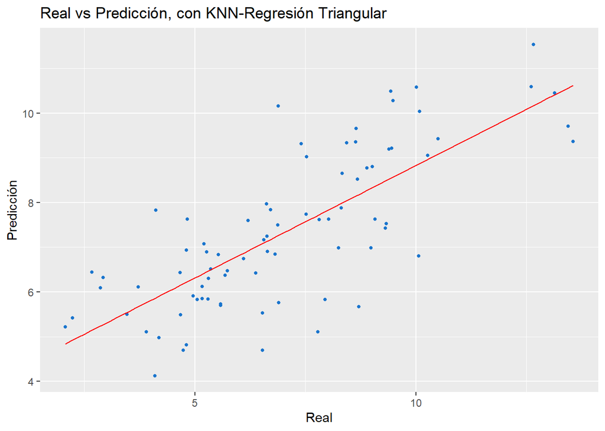

```r
g <- plot.real.prediccion(testing$Ventas, prediccion$prediction, modelo = "KNN-Regresión Triangular")
g + geom_smooth(method = lm, size = 0.4, color = "red", se = FALSE)
```

### Epanechnikov

```r
modelo.epanechnikov <- train.knn(Ventas~., data = aprendizaje, kernel = "epanechnikov")

prediccion <- predict(modelo.epanechnikov, testing)

pre.epanechnikov <- indices.precision(testing$Ventas ,prediccion$prediction,numero.predictoras)

pre.epanechnikov
```

```
$error.cuadratico
[1] 2.990026

$raiz.error.cuadratico
[1] 1.889492

$error.relativo
[1] 0.1913502

$correlacion
[1] 0.7628787
```

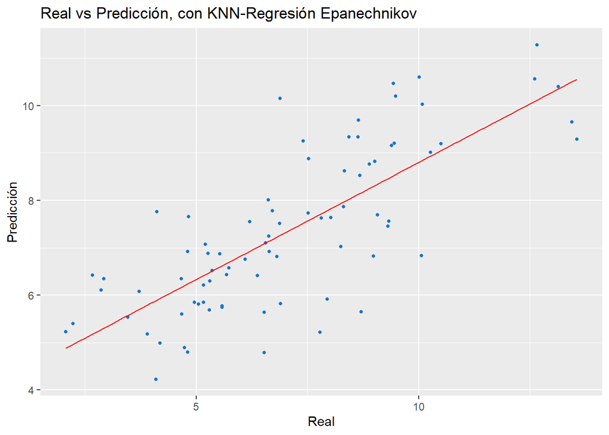

```r
g <- plot.real.prediccion(testing$Ventas, prediccion$prediction, modelo = "KNN-Regresión Epanechnikov")

g + geom_smooth(method = lm, size = 0.4, color = "red", se = FALSE)
```

### Biweight

```r
modelo.biweight <- train.knn(Ventas~., data = aprendizaje, kernel = "biweight")

prediccion <- predict(modelo.biweight, testing)

pre.biweight <- indices.precision(testing$Ventas ,prediccion$prediction,numero.predictoras)

pre.biweight
```

```
$error.cuadratico
[1] 3.225296

$raiz.error.cuadratico
[1] 1.962422

$error.relativo
[1] 0.1964851

$correlacion
[1] 0.7305012
```

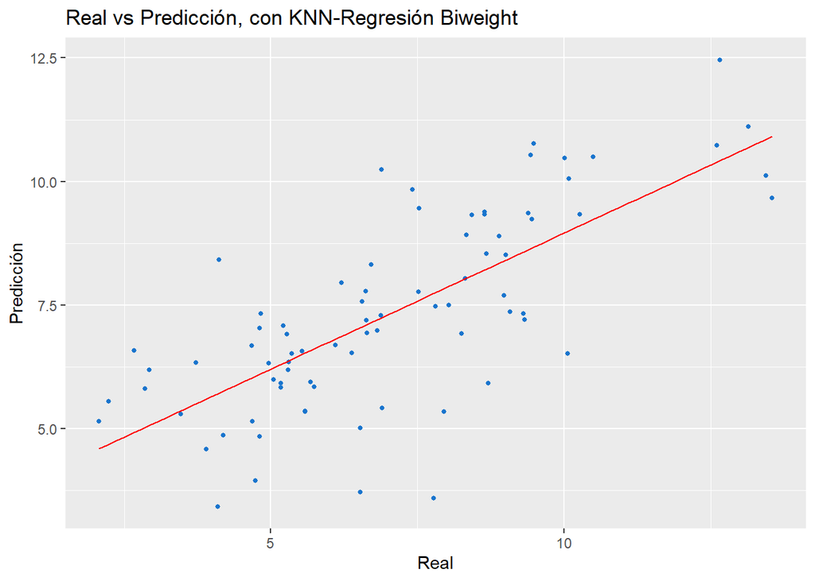

```r
g <- plot.real.prediccion(testing$Ventas, prediccion$prediction, modelo = "KNN-Regresión Biweight")
g + geom_smooth(method = lm, size = 0.4, color = "red", se = FALSE)
```

### Triweight

```r
modelo.triweight <- train.knn(Ventas~., data = aprendizaje, kernel = "triweight")

prediccion <- predict(modelo.triweight, testing)

pre.triweight <- indices.precision(testing$Ventas ,prediccion$prediction,numero.predictoras)

pre.triweight
```

```
$error.cuadratico
[1] 3.672695

$raiz.error.cuadratico
[1] 2.094113

$error.relativo
[1] 0.2093382

$correlacion
[1] 0.6949757
```

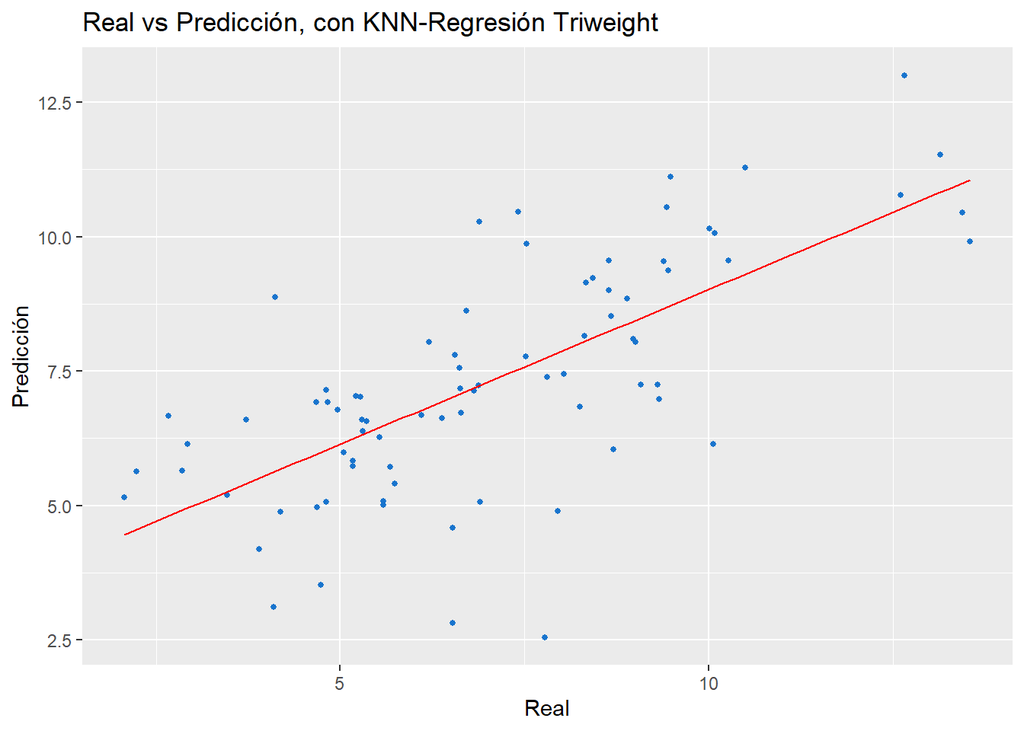

```r
g <- plot.real.prediccion(testing$Ventas, prediccion$prediction, modelo = "KNN-Regresión Triweight")
g + geom_smooth(method = lm, size = 0.4, color = "red", se = FALSE)
```

### Cos

```r
modelo.cos <- train.knn(Ventas~., data = aprendizaje, kernel = "cos")

prediccion <- predict(modelo.cos, testing)

pre.cos <- indices.precision(testing$Ventas ,prediccion$prediction,numero.predictoras)

pre.cos
```

```
$error.cuadratico
[1] 2.988506

$raiz.error.cuadratico
[1] 1.889012

$error.relativo
[1] 0.1909801

$correlacion
[1] 0.7617792
```

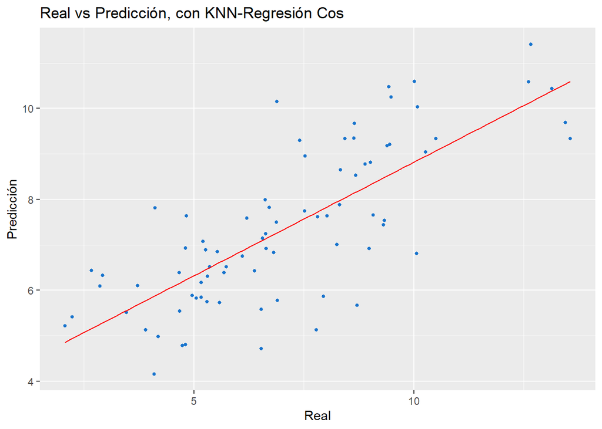

```r
g <- plot.real.prediccion(testing$Ventas, prediccion$prediction, modelo = "KNN-Regresión Cos")
g + geom_smooth(method = lm, size = 0.4, color = "red", se = FALSE)
```

### inv

```r
modelo.inv <- train.knn(Ventas~., data = aprendizaje, kernel = "inv")

prediccion <- predict(modelo.inv, testing)

pre.inv <- indices.precision(testing$Ventas ,prediccion$prediction,numero.predictoras)

pre.inv
```

```
$error.cuadratico
[1] 3.089417

$raiz.error.cuadratico
[1] 1.920639

$error.relativo
[1] 0.192916

$correlacion
[1] 0.7634592
```

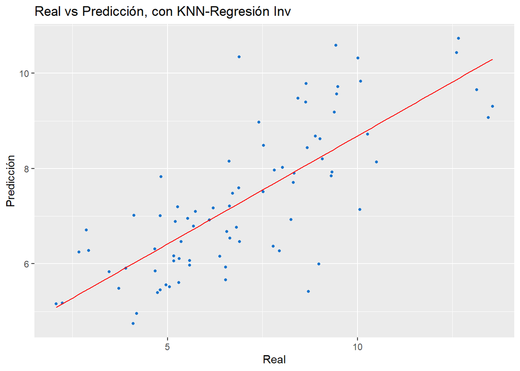

```r
g <- plot.real.prediccion(testing$Ventas, prediccion$prediction, modelo = "KNN-Regresión Inv")
g + geom_smooth(method = lm, size = 0.4, color = "red", se = FALSE)
```

### Gaussian

```r
modelo.gaussian <- train.knn(Ventas~., data = aprendizaje, kernel = "gaussian")

prediccion <- predict(modelo.gaussian, testing)

pre.gaussian <- indices.precision(testing$Ventas ,prediccion$prediction,numero.predictoras)

pre.gaussian
```

```
$error.cuadratico
[1] 3.042392

$raiz.error.cuadratico
[1] 1.905966

$error.relativo
[1] 0.1916507

$correlacion
[1] 0.7668571
```

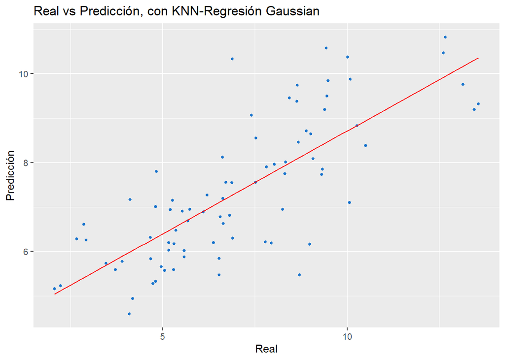

```r
g <- plot.real.prediccion(testing$Ventas, prediccion$prediction, modelo = "KNN-Regresión Gaussian")
g + geom_smooth(method = lm, size = 0.4, color = "red", se = FALSE)
```

### Optimal

```r
modelo.optimal <- train.knn(Ventas~., data = aprendizaje, kernel = "optimal")

prediccion <- predict(modelo.optimal, testing)

pre.optimal <- indices.precision(testing$Ventas ,prediccion$prediction,numero.predictoras)

pre.optimal
```

```
$error.cuadratico
[1] 3.039983

$raiz.error.cuadratico
[1] 1.905211

$error.relativo
[1] 0.1943412

$correlacion
[1] 0.7567205
```

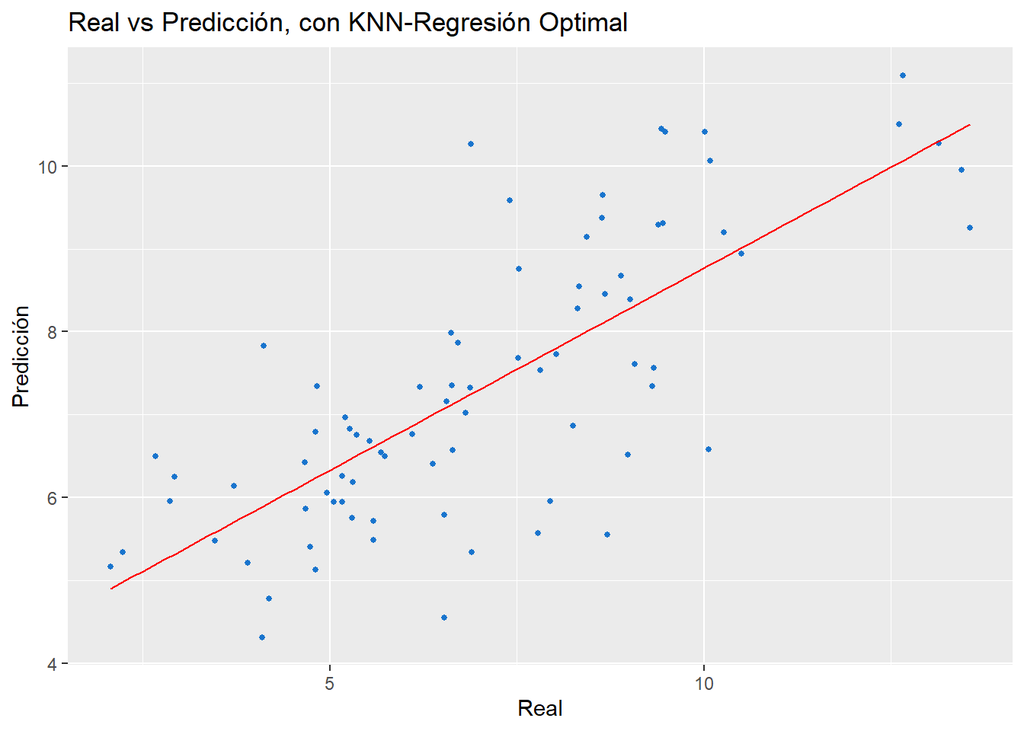

```r
g <- plot.real.prediccion(testing$Ventas, prediccion$prediction, modelo = "KNN-Regresión Optimal")
g + geom_smooth(method = lm, size = 0.4, color = "red", se = FALSE)
```

No hubo mucha diferencia en los resultados, el modelo no mejoró o empeoró significativamente.Sin embargo, el mejor núcleo esta vez fue `triangular`.